# Roman WFI sRCS — LED Precharge & Step-Aware "Credit"

**Purpose.** A short, runnable explainer of (1) how sRCS LED precharge is computed and (2) how to *credit* an already-lit LED so consecutive up-steps don't re-charge from scratch. Worked on the LOLO flux sweep (2 → 20 → 200 → 500 e⁻/pix/s).

Calibration source: `260401_sRCS_WFI_Calibration.xlsx` (flux cal + LED current curves), validated Side-B precharge constants `{band4: 2164, band5: 1300, band6: 1040}` mA·s/mA.

## 1. The precharge model

The empirical result is that the **extra charge** needed to settle an LED is proportional to the **drive current** at the target flux:

$$ Q_{\text{settle}} \;=\; pc_{\text{band}} \times I_{\text{target}} $$

where $pc_{\text{band}}$ is a per-band constant in mA·s per mA of final current (measured from cold). To deliver that charge in a fixed precharge **duration** $t_{pc}$ (30 s), the precharge **current** is:

$$ I_{pc} \;=\; \frac{Q_{\text{settle}}}{t_{pc}} \;=\; I_{\text{target}}\,\frac{pc_{\text{band}}}{t_{pc}} $$

We then convert $I_{pc}$ back to a *flux-equivalent* for the command (`PRECHARGE_FLUX`). If $I_{pc}$ exceeds the LED hardware max, we clamp the current and **extend the duration** instead (capped at 300 s).

```python
import pandas as pd, numpy as np, math
import matplotlib.pyplot as plt

WB = '/workspace/users/lane-meier-U07L2GFEEJ1/uploads/260401_sRCS_WFI_Calibration.xlsx'

# --- 4/01 Side-B (box 2) flux calibration + LED current curves ---
flux = pd.read_excel(WB, 'H4RG Flux Calibration'); flux = flux[flux.box == 2]
LMAX='<= low max flux\n[e-/pix/s]'; HMIN='> high min flux\n[e-/pix/s]'; HMAX='high max flux\n[e-/pix/s]'
FT = {(int(r.band), int(r.bank)): r for _, r in flux.iterrows()}
led = pd.read_excel(WB, 'LED Calibration'); led = led[led.box == 2]
CV = {int(r.bank): r for _, r in led.iterrows()}

# validated Side-B precharge constants (mA*s / mA)
PC = {4: 2164, 5: 1300, 6: 1040}

def f2code(b, k, fl):
    r = FT[(b, k)]
    if fl <= r[LMAX]:
        return r['L^3']*fl**3 + r['L^2']*fl**2 + r['L^1']*fl + r['L^0']
    return r['H^3']*fl**3 + r['H^2']*fl**2 + r['H^1']*fl + r['H^0']

def code2flux(code, b, k):
    r = FT[(b, k)]
    if code <= 65535:
        roots = np.roots([r['L^3'], r['L^2'], r['L^1'], r['L^0'] - code])
        re = roots[np.abs(roots.imag) < 1e-6].real
        cand = re[(re > 0) & (re <= r[LMAX]*1.2)]
        return float(cand.min()) if len(cand) else float(re.max())
    return float((code - r['H^0']) / r['H^1'])

def cur2code(k, i_mA):
    cv = CV[k]; i = i_mA/1e3
    thresh = (65535 - cv['low b'])/cv['low m']
    return round(i*cv['high m'] + cv['high b'], 0) if i > thresh else round(i*cv['low m'] + cv['low b'], 0)

def code2cur(k, code):
    cv = CV[k]; code = int(code)
    return (code - cv['high b'])/cv['high m'] if code > 65536 else (code - cv['low b'])/cv['low m']

def flux_to_current_mA(b, k, fl):
    return code2cur(k, f2code(b, k, fl)) * 1e3
print('Loaded 4/01 calibration. Precharge constants (Side B):', PC)
```

```
Loaded 4/01 calibration. Precharge constants (Side B): {4: 2164, 5: 1300, 6: 1040}
```

## 2. From-dark precharge (one function)

`precharge_flux(band, bank, target_flux, prev_flux)` — with `prev_flux=0` it charges from **dark** (the cold, full-current case).

```python
def precharge_flux(band, bank, target_flux, prev_flux=0.0, duration=30.0, pc=PC):
    # Returns (precharge_flux, duration).
    #   prev_flux = 0  -> from dark (full current)
    #   prev_flux > 0  -> step-aware credit (only the incremental charge)
    I_target = flux_to_current_mA(band, bank, target_flux)
    I_prev   = flux_to_current_mA(band, bank, prev_flux) if prev_flux else 0.0
    I_step   = I_target - I_prev                      # <-- the only difference vs from-dark
    I_pc     = I_step * pc[band] / duration
    if cur2code(bank, I_pc) > 2*65535 - 1:            # hardware clamp -> extend duration
        I_pc = flux_to_current_mA(band, bank, FT[(band,bank)][HMAX] - 2)
        duration = math.ceil(I_step * pc[band] / I_pc)
        I_pc = I_step * pc[band] / duration
    return round(code2flux(cur2code(bank, I_pc), band, bank), 1), round(duration, 1)

# from dark, band 4 (LED14), bank 1:
for f in [2, 20, 200, 500]:
    print(f'flux {f:>4} -> precharge_flux {precharge_flux(4,1,f)[0]:>9} e-/pix/s (from dark)')
```

```
flux    2 -> precharge_flux     319.0 e-/pix/s (from dark)
flux   20 -> precharge_flux    2275.0 e-/pix/s (from dark)
flux  200 -> precharge_flux   15797.0 e-/pix/s (from dark)
flux  500 -> precharge_flux   37423.6 e-/pix/s (from dark)
```

## 3. Step-aware "credit" — the key idea

When you sweep a single LED **upward** in flux *without turning it off* (LOLO does 2 → 20 → 200 → 500), the LED is **already charged** to the previous level's equilibrium. So you only need to supply the **incremental** charge:

$$ I_{pc} \;=\; \big(I_{\text{target}} - I_{\text{prev}}\big)\,\frac{pc_{\text{band}}}{t_{pc}} $$

- **First step** of a sweep (LED cold): $I_{\text{prev}} = 0$ → identical to from-dark.
- **Each up-step**: credit the previous equilibrium → smaller precharge current.

This is the *only* change: subtract the current the LED already holds.

### How the credit is "spent": decay, not a switch

The charge state isn't a latch — it **decays over time** once the LED is off. From the bench data, leaving an LED off for roughly **10 minutes** decays it back to (effectively) the cold, fully-discharged state, so the next turn-on should again be charged from dark.

`CLEANUP=YES` in the APT is just a **heuristic flag for that decay**: it marks the end of a sweep, after which enough off-time elapses (sequencing, other LEDs, other observations) that the LED is back to cold. In other words, we model it as binary — *credit while the LED stays lit/recently-lit within a sweep; back to dark by the next time it's used* — because in these sequences the gap between a cleanup and the LED's next use comfortably exceeds the ~10 min decay. If a future sequence re-used the same LED **within** ~10 minutes of switching it off, the from-dark assumption would be slightly conservative (the LED would still hold partial charge) and the precharge could be credited further.

```python
sweep = [2.0, 20.0, 200.0, 500.0]
rows = []
for band, ledname in [(4,'LED14'), (5,'LED15'), (6,'LED16')]:
    prev = 0.0
    for f in sweep:
        fd, _ = precharge_flux(band, 1, f, prev_flux=0.0)     # naive: from dark every step
        cr, _ = precharge_flux(band, 1, f, prev_flux=prev)    # step-aware credit
        rows.append(dict(LED=ledname, band=band, flux=f,
                         from_dark=fd, with_credit=cr,
                         reduction=f'{100*(1-cr/fd):.0f}%' if fd else '-'))
        prev = f   # carry equilibrium forward within the sweep; LED decays to cold
                   # (~10 min off) before its next use, so the next sweep starts from dark
df = pd.DataFrame(rows)
df
```

|  | LED | band | flux | from_dark | with_credit | reduction |
| --- | --- | --- | --- | --- | --- | --- |
| 0 | LED14 | 4 | 2.0 | 319.0 | 319.0 | 0% |
| 1 | LED14 | 4 | 20.0 | 2275.0 | 1935.9 | 15% |
| 2 | LED14 | 4 | 200.0 | 15797.0 | 13501.9 | 15% |
| 3 | LED14 | 4 | 500.0 | 37423.6 | 21606.4 | 42% |
| 4 | LED15 | 5 | 2.0 | 131.2 | 131.2 | 0% |
| 5 | LED15 | 5 | 20.0 | 1054.6 | 925.9 | 12% |
| 6 | LED15 | 5 | 200.0 | 8557.0 | 7504.2 | 12% |
| 7 | LED15 | 5 | 500.0 | 21568.2 | 13013.8 | 40% |
| 8 | LED16 | 6 | 2.0 | 114.7 | 114.7 | 0% |
| 9 | LED16 | 6 | 20.0 | 824.4 | 711.9 | 14% |
| 10 | LED16 | 6 | 200.0 | 6721.7 | 5902.5 | 12% |
| 11 | LED16 | 6 | 500.0 | 17130.3 | 10413.9 | 39% |

The `with_credit` column is what goes into the APT `PRECHARGE_FLUX`. Note the first row of each LED (`flux = 2`) is unchanged (cold), while the up-steps drop — most dramatically the bright **500** point, which no longer re-charges from scratch.

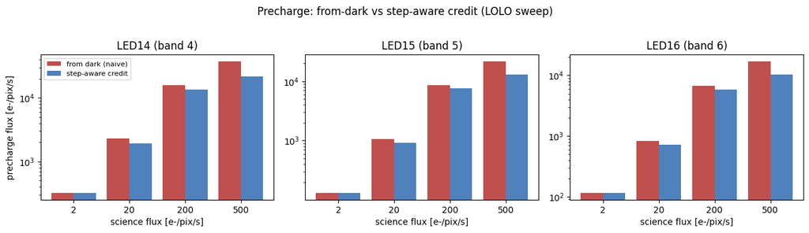

```python
fig, axes = plt.subplots(1, 3, figsize=(13, 3.6), sharex=True)
for ax, (band, ledname) in zip(axes, [(4,'LED14'),(5,'LED15'),(6,'LED16')]):
    d = df[df.band == band]
    x = np.arange(len(sweep))
    ax.bar(x-0.2, d.from_dark, 0.4, label='from dark (naive)', color='#c0504d')
    ax.bar(x+0.2, d.with_credit, 0.4, label='step-aware credit', color='#4f81bd')
    ax.set_yscale('log'); ax.set_xticks(x); ax.set_xticklabels([int(s) for s in sweep])
    ax.set_title(f'{ledname} (band {band})'); ax.set_xlabel('science flux [e-/pix/s]')
axes[0].set_ylabel('precharge flux [e-/pix/s]'); axes[0].legend(fontsize=8)
plt.suptitle('Precharge: from-dark vs step-aware credit (LOLO sweep)', y=1.02)
plt.tight_layout(); plt.show()
```

## 4. How to apply it in a sequence (recipe)

1. **Group** rows into sweeps: one sweep = consecutive rows for the **same LED** that stay on together (in LOLO, one `OBSERVATION_NUMBER`). Order by ascending flux.
2. **First row** of a sweep → `prev = 0` (from dark).
3. **Each subsequent row** → `prev = previous row's flux` (credit).
4. **End of sweep** (`CLEANUP = YES`) → the LED turns off and **decays back to cold** over the following off-time (~10 min fully discharges it). By the next time that LED is used it's cold again, so reset `prev = 0`. *Caveat:* if a sequence ever re-fires the same LED within ~10 min of cleanup, it still holds partial charge and could be credited further.
5. Only **IR bands 4–6** precharge; leave bands 1–3 blank.
6. Durations stay at 30 s unless the precharge current would exceed hardware (then extend, ≤300 s).

That's exactly how `APT_1024_LOLO_rev3.csv` was produced — and an independent recompute from the 4/01 calibration reproduces all 76 IR rows to within rounding (≤0.1 e⁻).